# **Exploratory Data Analysis for *SampleSuperstore***

## **Let’s take a look of our data set:**

```
##        Ship.Mode   Segment       Country            City      State Postal.Code
## 1   Second Class  Consumer United States       Henderson   Kentucky       42420
## 2   Second Class  Consumer United States       Henderson   Kentucky       42420
## 3   Second Class Corporate United States     Los Angeles California       90036
## 4 Standard Class  Consumer United States Fort Lauderdale    Florida       33311
## 5 Standard Class  Consumer United States Fort Lauderdale    Florida       33311
##   Region        Category Sub.Category    Sales Quantity Discount    Profit
## 1  South       Furniture    Bookcases 261.9600        2     0.00   41.9136
## 2  South       Furniture       Chairs 731.9400        3     0.00  219.5820
## 3   West Office Supplies       Labels  14.6200        2     0.00    6.8714
## 4  South       Furniture       Tables 957.5775        5     0.45 -383.0310
## 5  South Office Supplies      Storage  22.3680        2     0.20    2.5164
```

## **The quick summary about the data set is:**

```
##   Ship.Mode           Segment            Country              City
##  Length:9994        Length:9994        Length:9994        Length:9994
##  Class :character   Class :character   Class :character   Class :character
##  Mode  :character   Mode  :character   Mode  :character   Mode  :character
##
##
##
##     State            Postal.Code       Region            Category
##  Length:9994        Min.   : 1040   Length:9994        Length:9994
##  Class :character   1st Qu.:23223   Class :character   Class :character
##  Mode  :character   Median :56431   Mode  :character   Mode  :character
##                     Mean   :55190
##                     3rd Qu.:90008
##                     Max.   :99301
##  Sub.Category           Sales              Quantity        Discount
##  Length:9994        Min.   :    0.444   Min.   : 1.00   Min.   :0.0000
##  Class :character   1st Qu.:   17.280   1st Qu.: 2.00   1st Qu.:0.0000
##  Mode  :character   Median :   54.490   Median : 3.00   Median :0.2000
##                     Mean   :  229.858   Mean   : 3.79   Mean   :0.1562
##                     3rd Qu.:  209.940   3rd Qu.: 5.00   3rd Qu.:0.2000
##                     Max.   :22638.480   Max.   :14.00   Max.   :0.8000
##      Profit
##  Min.   :-6599.978
##  1st Qu.:    1.729
##  Median :    8.666
##  Mean   :   28.657
##  3rd Qu.:   29.364
##  Max.   : 8399.976
```

## **Check the Number of missing values in the data set**

```
## [1] 0
```

So as we can see, there are no missing values in the data set.

## **Now, we are going to understand the summary of data using different graphs.**

### **The proportion of Profit and Sales in different regions of the country**

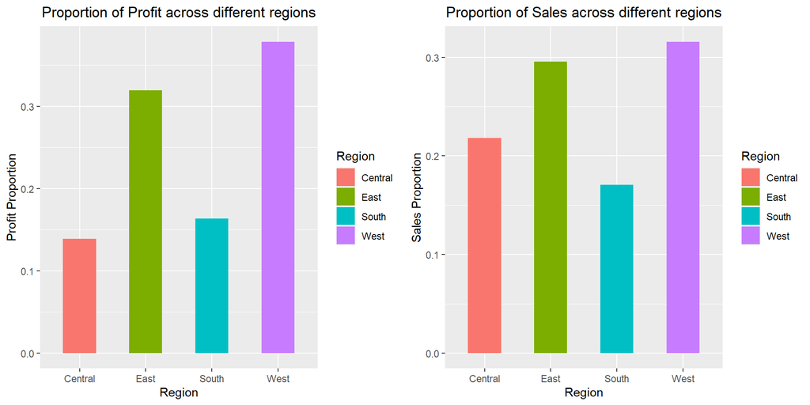

### **Total Sales across different Sates of different regions of the country**

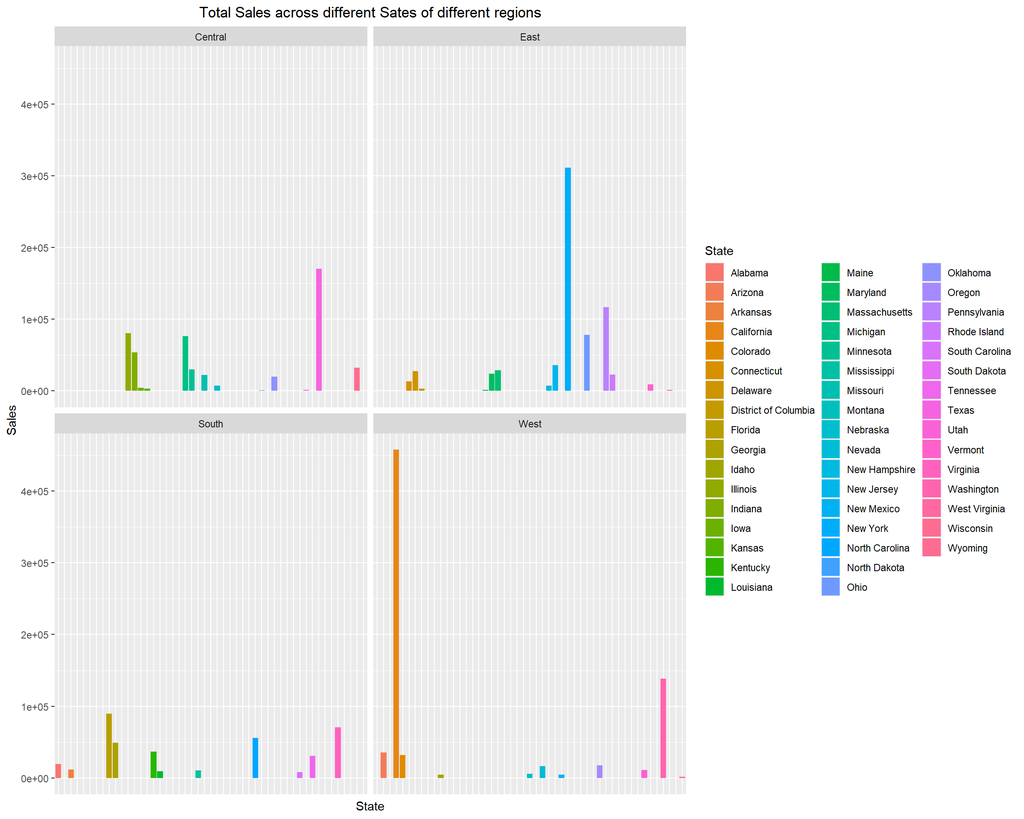

### **Profit per Sale across different States of different regions of the country**

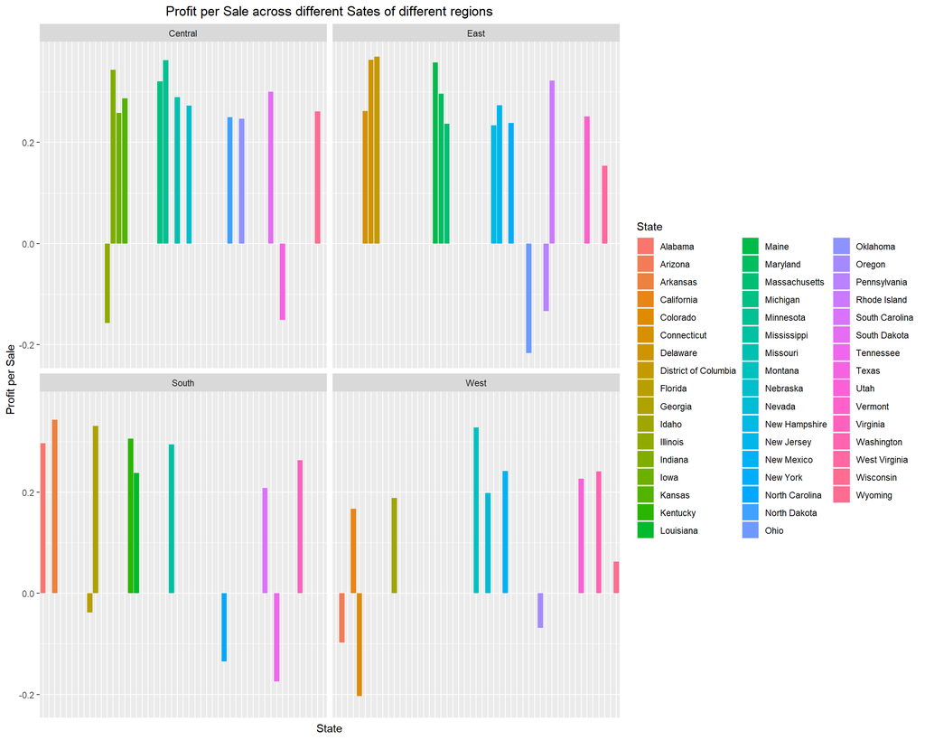

### **Number of different Ship modes in different regions of the country**

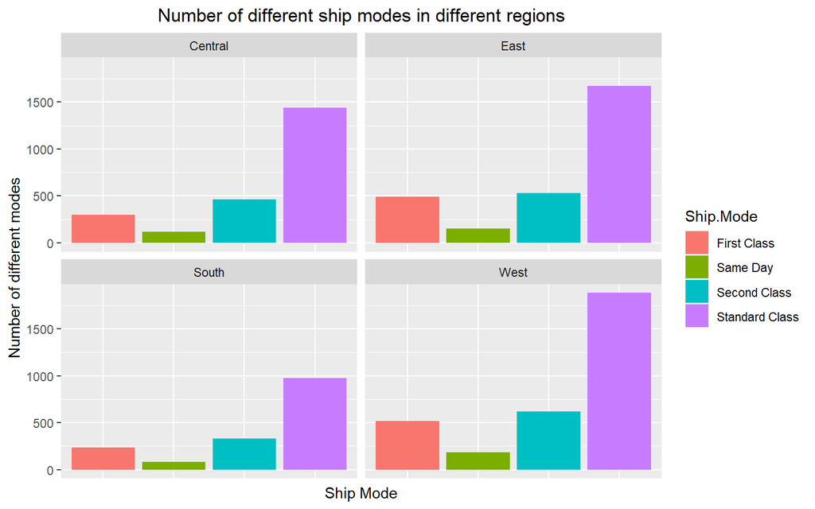

### **Sales on using different Ship modes in different regions**

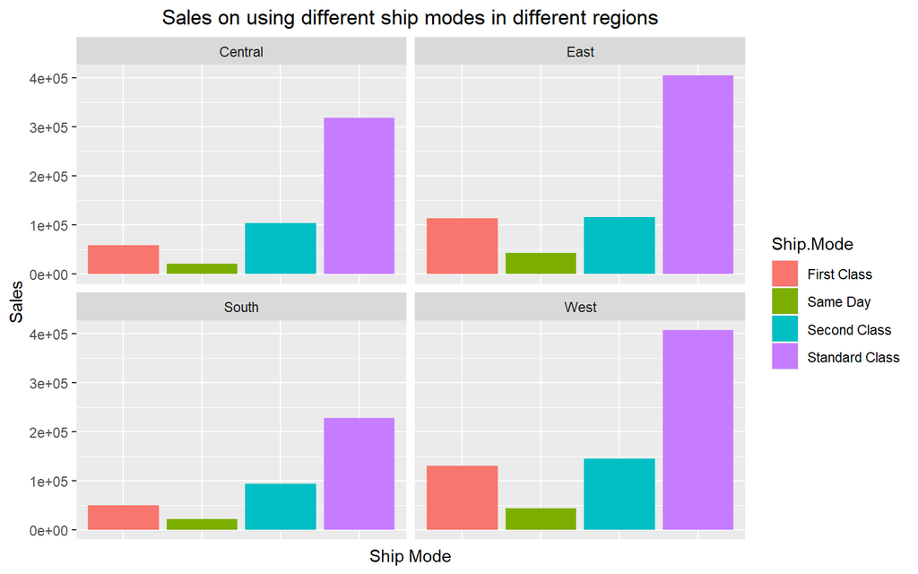

### **How different Ship modes are affecting Profit in different regions of the country?**

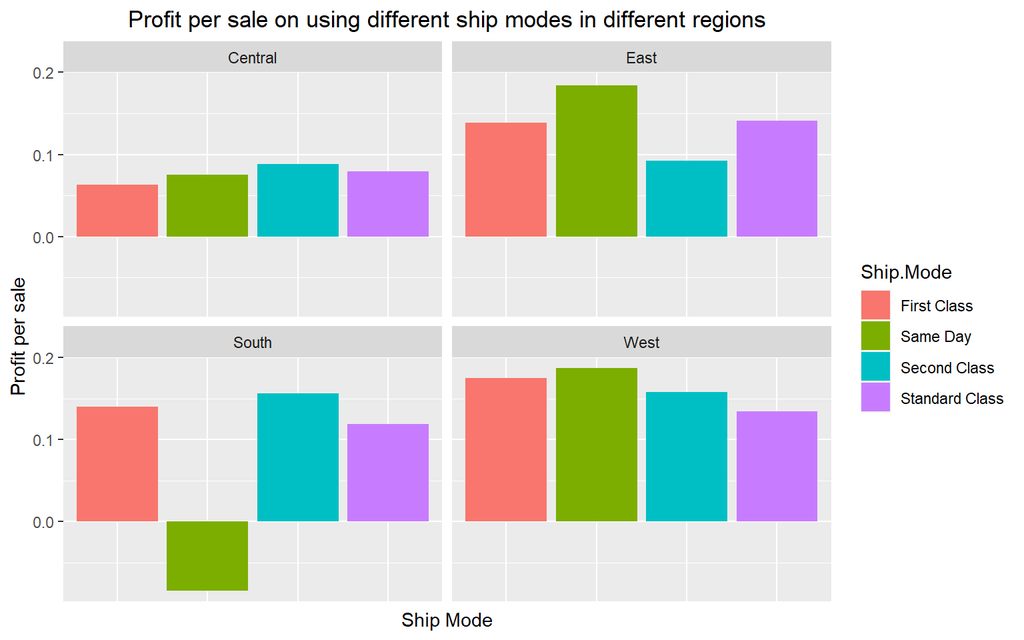

It can be optically discerned from the above graph that, *Same day* Ship mode is not a good option for the South region. To truncate loss and increment profit in the South region, other modes should be habituated as shipping modes like *First Class*, *Second Class*, and *Standard Class*. On the other hand, in the East and West regions *same day* ship mode is preferable. Withal, Profit may be incremented in the Central region if we utilize *same day* Ship mode, as in the East and West regions.

### **Number of different Customer segments in different regions of the country**

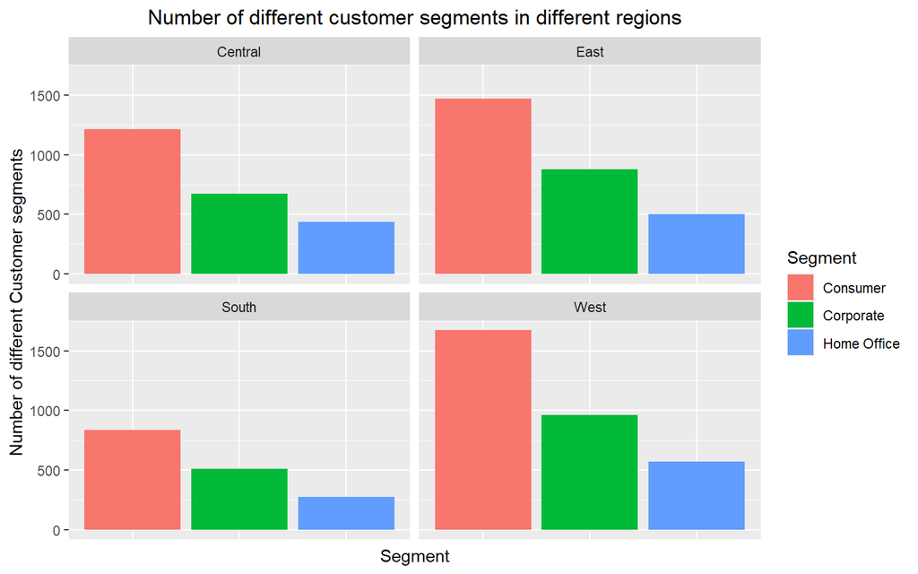

### **Sales in different segments in different regions of the country**

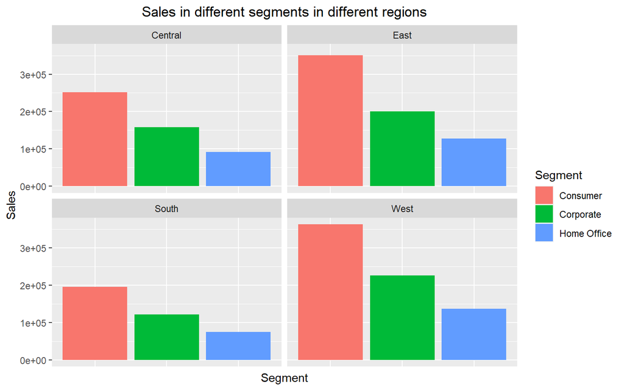

### **What is the Profit per Sale in different segments in different regions of the country?**

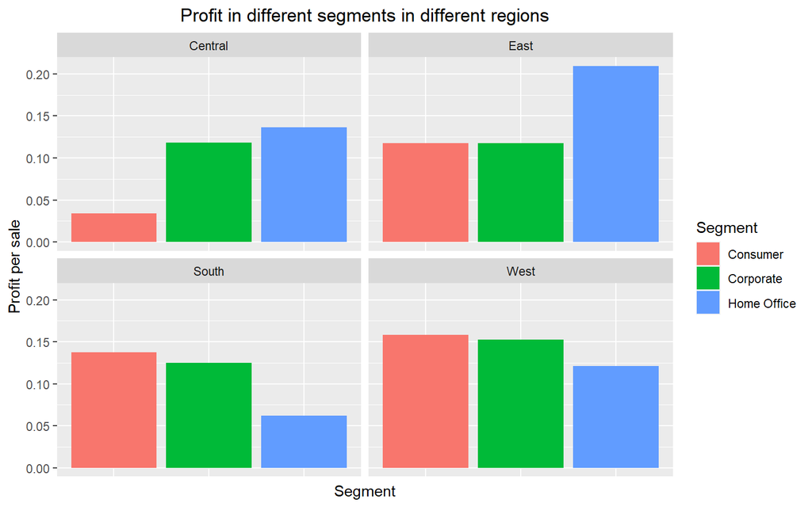

In the Central region, *Consumer* segment profit is very low. Increment the profit in this segment to increment the overall profit in the business. On the other hand, in the South region, the *Home office* segment should be ameliorated for more profit.

### **Sales of different categories with different Subcategory shares in different regions of the country**

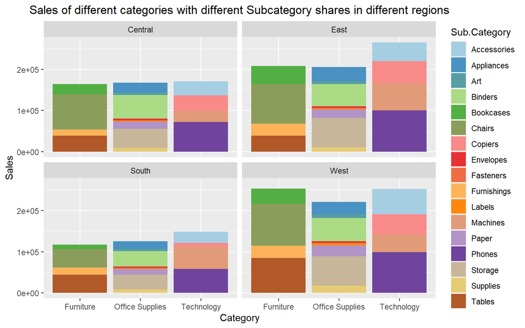

### **Describe the Profit per sale on different Categories with different Subcategory shares in different regions of the country?**

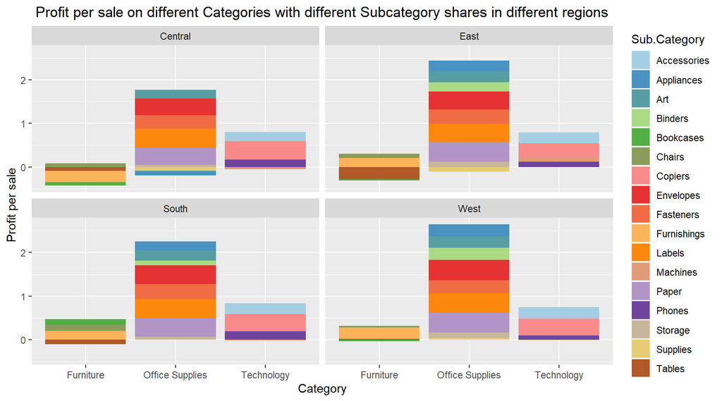

It is to be noted from the above graph that in the Central region, *Furniture* category products are in astronomically immense loss, more accurately in its *Furnishings* products. So the attention should be made towards these products in the Central region to minimize loss and making a good profit. Withal, there are few products in *Office Supplies* and *Technology* which are in loss. In the East region withal, *Furniture* category products are in loss, in which *Tables* are playing a major role. It additionally has a loss in *Office Supply* category products. so there is a desideratum to look into these categories to truncate loss and making a profit. In the other two regions, there is not as much loss as are in the Central and East regions, but still there is a loss in *Furniture* in the South and West regions.

## **Understanding each Region for the loss in their respective States. Additionally, ascertaining ways to increment profit and truncate loss.**

## **Analysing the Central region**

### **Giving higher discount for more Sales and Profit? Let’s visually perceive how higher discount rates are impacting Profit per sale in the States of Central Region. Additionally which are the States suffering more preponderant loss?**

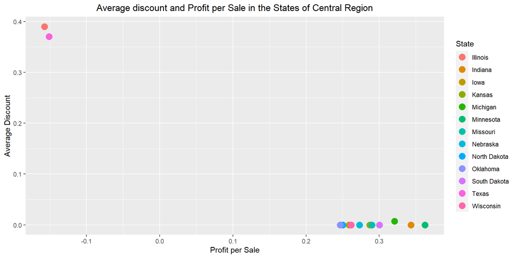

As we can optically discern from the above graph that verbalizes, *Texas* and *Illinois*, which are giving higher loss, are availing higher average discount rates of around 30% - 40%. But in the other states, albeit receiving negligible or no discounts are giving a good profit. These higher discount rates are the major factor for the loss in these states. So to increment Profit in the Central region discount rates must be decremented, especially in *Texas* and *Illinois*.

### **Now, ascertain the categories of different Sales in States of Texas and Illinois on which discount rates are high?**

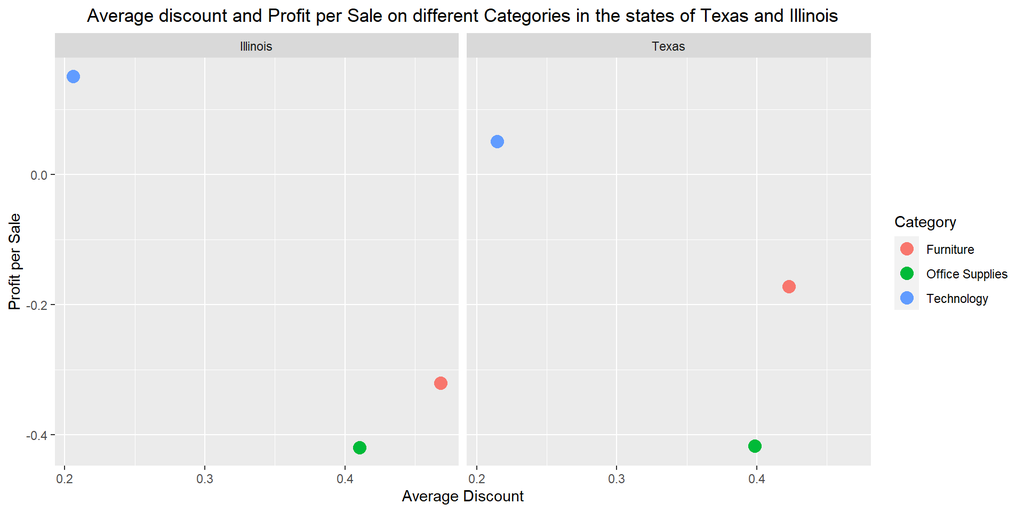

As it can be optically discerned that in both the states, Texas and Illinois, discount rates are high only in the sales of categories *Office Supply* and *Furniture*. To decrement the rates for these categories will minimize loss in these states and increment profit.